# Reproductible Research Assignment 1

## Synopsis

The purpose of this assignment is to practice: * loading data using markdown * processing and drawing conclusions from data * learning mardown syntax

Also, set all code echo = TRUE

## Reading in data and processing

```r
activityData <- read.csv("activity.csv", colClasses = c("integer", "Date", "integer"))
```

## What is the mean total number of steps taken each day?

```r
library(ggplot2)

totalSteps <- aggregate(data=activityData, steps ~ date, na.rm = TRUE, sum)

summary(totalSteps)
```

```
##       date                steps
##  Min.   :2012-10-02   Min.   :   41
##  1st Qu.:2012-10-16   1st Qu.: 8841
##  Median :2012-10-29   Median :10765
##  Mean   :2012-10-30   Mean   :10766
##  3rd Qu.:2012-11-16   3rd Qu.:13294
##  Max.   :2012-11-29   Max.   :21194
```

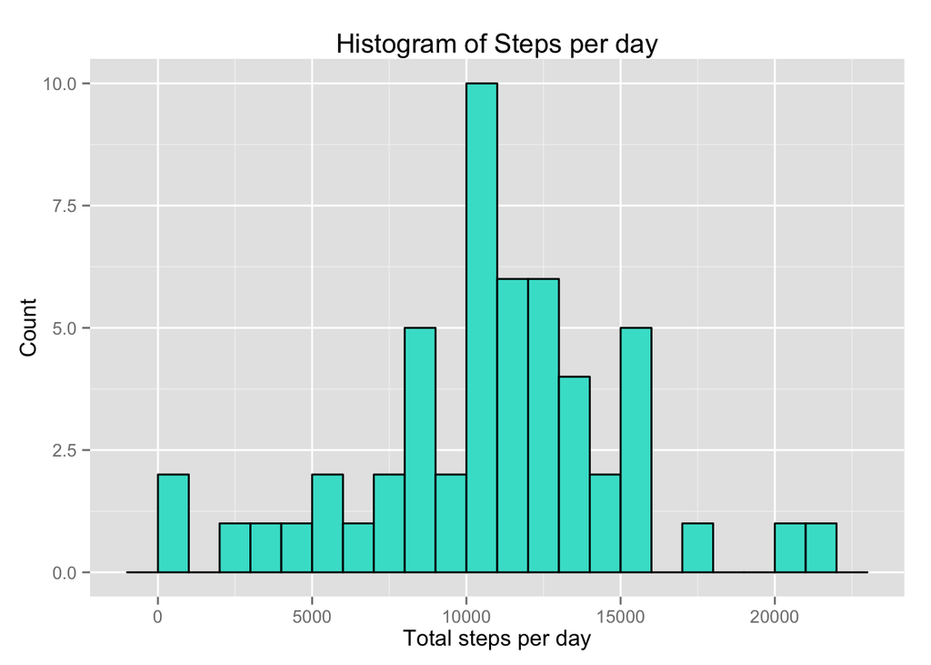

```r
ggplot(data=totalSteps, aes(steps)) + geom_histogram(width = 1.5, bins = 20, binwidth = 1000, col = "black", fill = "turquoise") +

  labs(x = "Total steps per day") +
  labs(y = "Count") +
  labs(title = "Histogram of Steps per day")
```

to calculate the mean we can simply call the mean and median function on our processed data

```r
stepsmean <- round(mean(totalSteps$steps, na.rm = TRUE), digits = 5)
stepsmedian <- median(totalSteps$steps, na.rm = TRUE)
```

## What is the average daily activity pattern?

We need to compute the average (mean) steps per interval first…then plot the daily average activity

```r
intervalSteps <- aggregate(data=activityData, steps ~ interval, na.rm = TRUE, mean)
intervalSteps$steps <- round(intervalSteps$steps, digits = 0)
```

### Plot the line chart of the average daily activity

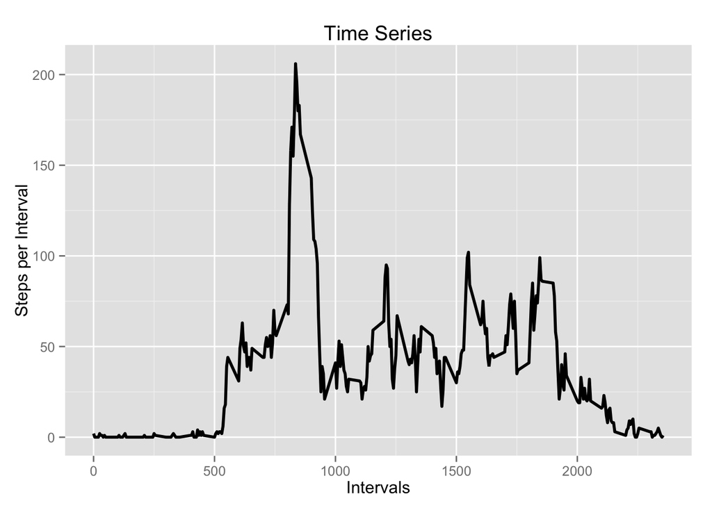

```r
library(ggplot2)

ggplot(intervalSteps, aes(interval, steps)) +
    geom_line(color = "black", stat = "identity",
              size = 1, na.rm = TRUE) +

    labs(x = "Intervals") +
    labs(y = "Steps per Interval") +
    labs(title = "Time Series")
```

### Which interval, on average across all the days in the dataset, contains the maximum number of steps?

```r
intervalSteps[which.max((intervalSteps$steps)),]
```

```
##     interval steps
## 104      835   206
```

## Imputing missing values

Total number of missing values (NAs)

```r
sum(is.na(activityData))
```

```
## [1] 2304
```

### Impute missing values

Using the mean for a given time interval, we can impute data irrespective of actual time. We need to loop over all steps in a given interval in order to aggregate the steps per day on the full data set, with imputed values.

```r
index <- nrow(activityData)
for(n in 1:index) {
    if (is.na(activityData$steps[n])) {
        activityData$steps[n] <- intervalSteps[which(activityData$interval[n]
                                               == intervalSteps$interval), ]$steps
    }
}
```

```r
intervalStepsFilled <- aggregate(steps ~ date, activityData, sum)
```

```r
stepsmeanFilled <- round(mean(intervalStepsFilled$steps), digits = 0)
stepsmedianFilled <- median(intervalStepsFilled$steps)
```

### Histogram of data file with imuputed values

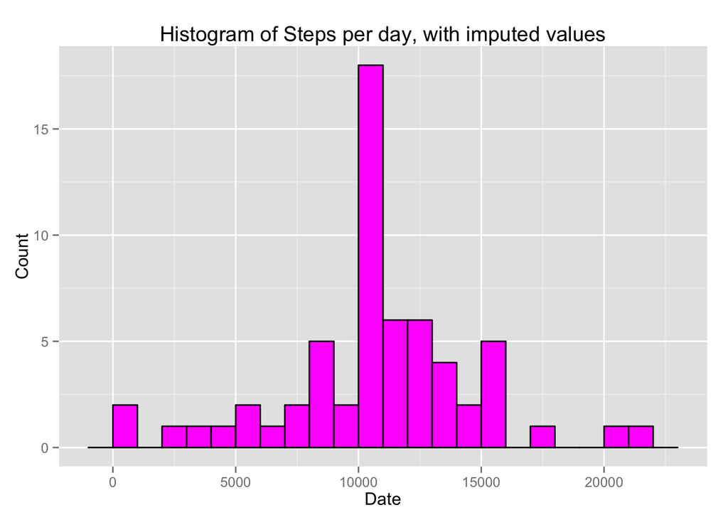

```r
library(ggplot2)


ggplot(data=intervalStepsFilled, aes(steps)) + geom_histogram(width = 1.5, bins = 20, binwidth = 1000, col = "black", fill = "magenta") +

  labs(x = "Date") +
  labs(y = "Count") +
  labs(title = "Histogram of Steps per day, with imputed values")
```

### Are there differences in activity patterns between weekdays and weekends?

First, find the day of the week for each measurement in the dataset.

```r
activityData$weekday <- with(activityData, weekdays(activityData$date, abbreviate=FALSE))

for (n in 1:index) {
  if (activityData$weekday[n] != "Saturday" &&
      activityData$weekday[n] != "Sunday" ) {
        activityData$weekday[n] <- "weekday"

  } else {
        activityData$weekday[n] <-"weekend"
      }



}
```

Aggregate the steps for interval for weekend and weekdays

```r
activityData$weekday <- as.factor(activityData$weekday)
intervalStepsFilled <- aggregate(steps ~ interval + weekday, activityData, mean)
intervalStepsFilled$steps <- round(intervalStepsFilled$steps, digits = 0)
```

### Plot the line chart in two panels

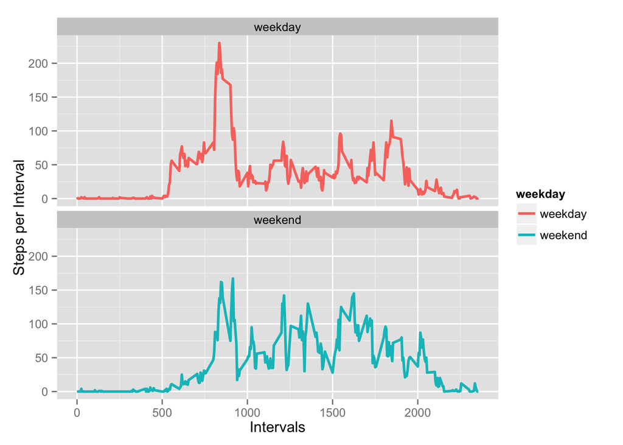

```r
library(ggplot2)

ggplot(intervalStepsFilled, aes(interval, steps, color = weekday)) +
  facet_wrap(~weekday, ncol = 1)+
  geom_line(stat = "identity", size = 1)+
  labs(x = "Intervals")+
  labs(y = "Steps per Interval")
```